# TP3 : Exercice 4 : la tension de vapeur du mercure

Tracy ANDRE

May 9th, 2023

#### **Q1 - Importation des données**

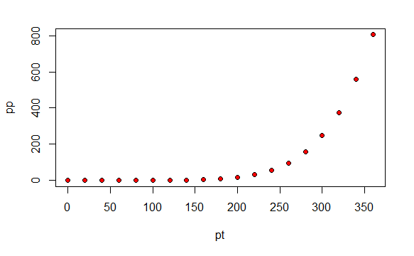

```r
library(datasets)
data("pressure")
pp <- pressure$pressure
pt <- pressure$temperature
plot(pt, pp, pch=21, bg="red")
```

On pourrait utilisé une fonction exponentielle (ou polynomiale)

```r
head(pressure)
```

|  | temperature | pressure |
| --- | --- | --- |
| 1 | 0 | 0.0002 |
| 2 | 20 | 0.0012 |
| 3 | 40 | 0.0060 |
| 4 | 60 | 0.0300 |
| 5 | 80 | 0.0900 |
| 6 | 100 | 0.2700 |

```r
summary(pressure)
```

```
  temperature     pressure
 Min.   :  0   Min.   :  0.0002
 1st Qu.: 90   1st Qu.:  0.1800
 Median :180   Median :  8.8000
 Mean   :180   Mean   :124.3367
 3rd Qu.:270   3rd Qu.:126.5000
 Max.   :360   Max.   :806.0000
```

#### **Q2 - Régression linéaire simple**

```r
model1 <- lm(log(pp)~pt, data = pressure)
summary(model1)
```

```
Call:
lm(formula = log(pp) ~ pt, data = pressure)

Residuals:
    Min      1Q  Median      3Q     Max
-2.4491 -0.6876  0.2866  0.8716  1.1365

Coefficients:
             Estimate Std. Error t value Pr(>|t|)
(Intercept) -6.068144   0.483831  -12.54 5.10e-10 ***
pt           0.039792   0.002296   17.33 3.07e-12 ***
---
Signif. codes:  0 ‘***’ 0.001 ‘**’ 0.01 ‘*’ 0.05 ‘.’ 0.1 ‘ ’ 1

Residual standard error: 1.096 on 17 degrees of freedom
Multiple R-squared:  0.9464,    Adjusted R-squared:  0.9433
F-statistic: 300.3 on 1 and 17 DF,  p-value: 3.07e-12
```

*Le modèle obtenu est-il fiable ?*

On peut évaluer la fiabilité du modèle obtenu avec le coefficient du R² : 0.9433 => Très proche de 1, il témoigne la qualité de l’ajustement du modèle au données d’entrainement.

On peut aussi observé le graphe des résidus pour savoir si les hypothèses sont valides :

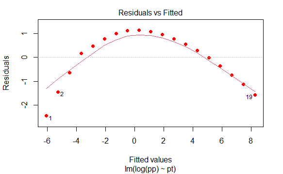

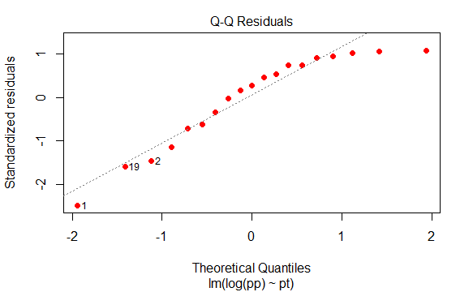

```r
plot(model1, col = "red", pch = 19, which = c(1,2))
```

Pour que les hypothèses soit valides et que le modèle soit fiable, il faut que les erreurs soit réparties de manière aléatoire et avec une variable constante, ce qui n’est pas le cas ici. De plus, le QQ plot nous montre bien que les erreurs ne s’alignent pas totalement avec la droite, ce qui signifie que les erreurs ne sont pas distribuées normalement.

*Donner les prédiction de la tension de la vapeur du mercure pour 90, 230, 400 degrés*

Pour 90°C :

```r
predict.lm(object = model1, newdata = data.frame(pt = 90), interval = "prediction", level = 0.95)
```

```
        fit       lwr         upr
1 -2.486874 -4.899888 -0.07386061
```

Pour 230°C :

```r
predict.lm(object = model1, newdata = data.frame(pt = 230), interval = "prediction", level = 0.95)
```

```
       fit       lwr      upr
1 3.083989 0.6983638 5.469615
```

Pour 400°C :

```r
predict.lm(object = model1, newdata = data.frame(pt = 400), interval = "prediction", level = 0.95)
```

```
       fit      lwr      upr
1 9.848609 7.246988 12.45023
```

#### **Q3 - Formule de Duprés**

*(a) Montrer que c’est une régression multiple*

$$ln(P) = \alpha_1 + \alpha_2*ln(T) + \frac{\alpha_3}{T}$$

*(b) Déterminer les valeurs estimées de* $\alpha_j$

```r
pt[1] <- pt[1] + 0.1
pressure$inv_pt <- 1/pt
model2 <- lm(log(pp)~log(pt)+inv_pt, data = pressure)
summary(model2)
```

```
Call:
lm(formula = log(pp) ~ log(pt) + inv_pt, data = pressure)

Residuals:
     Min       1Q   Median       3Q      Max
-0.84865 -0.47560 -0.04943  0.37122  1.77947

Coefficients:
            Estimate Std. Error t value Pr(>|t|)
(Intercept) -23.8136     1.0660  -22.34 1.73e-13 ***
log(pt)       5.0652     0.2097   24.16 5.11e-14 ***
inv_pt        2.6965     0.1694   15.92 3.11e-11 ***
---
Signif. codes:  0 ‘***’ 0.001 ‘**’ 0.01 ‘*’ 0.05 ‘.’ 0.1 ‘ ’ 1

Residual standard error: 0.6864 on 16 degrees of freedom
Multiple R-squared:  0.9802,    Adjusted R-squared:  0.9778
F-statistic: 396.8 on 2 and 16 DF,  p-value: 2.329e-14
```

*(c) Est-il + fiable que le précédant ?*

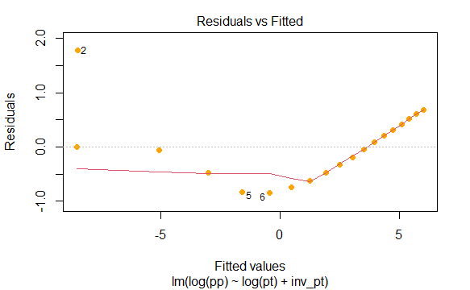

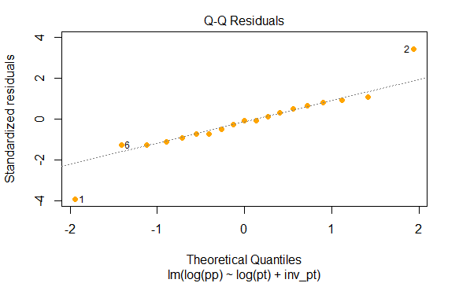

```r
plot(model2, col = "orange", pch = 19, which = c(1,2))
```

Les erreurs semblent ici bien s’aligner avec la courbe => suivent une loi normale

Par contre : pas distribué aléatoirement ?

La valeur du R² est de 0.98 ce qui est encore mieux que le modèle précédant

*(d) Mêmes prédictions*

Pour 90°C:

```r
predict.lm(object = model2, newdata = data.frame(pt = 90, inv_pt = 1/90), interval = "prediction")
```

```
         fit       lwr       upr
1 -0.9913535 -2.504027 0.5213197
```

Pour 230°C:

```r
predict.lm(object = model2, newdata = data.frame(pt = 230, inv_pt = 1/230), interval = "prediction")
```

```
       fit      lwr      upr
1 3.742908 2.236411 5.249405
```

Pour 400°C:

```r
predict.lm(object = model2, newdata = data.frame(pt = 400, inv_pt = 1/400), interval = "prediction")
```

```
       fit      lwr     upr
1 6.540917 4.985145 8.09669
```

#### **Q4 - Régression multiple encore**

```r
pressure$inv_carre <- pressure$inv_pt^2
model3 <- lm(log(pp)~log(pt) + inv_pt + inv_carre + pt, data = pressure)
summary(model3)
```

```
Call:
lm(formula = log(pp) ~ log(pt) + inv_pt + inv_carre + pt, data = pressure)

Residuals:
     Min       1Q   Median       3Q      Max
-0.12664 -0.04708  0.00000  0.05395  0.12800

Coefficients:
              Estimate Std. Error t value Pr(>|t|)
(Intercept) -29.290343   1.151812 -25.430 4.06e-13 ***
log(pt)       5.763160   0.253488  22.735 1.88e-12 ***
inv_pt      105.117268   9.115477  11.532 1.56e-08 ***
inv_carre   -10.171299   0.894690 -11.369 1.87e-08 ***
pt            0.005172   0.001123   4.606 0.000408 ***
---
Signif. codes:  0 ‘***’ 0.001 ‘**’ 0.01 ‘*’ 0.05 ‘.’ 0.1 ‘ ’ 1

Residual standard error: 0.07952 on 14 degrees of freedom
Multiple R-squared:  0.9998,    Adjusted R-squared:  0.9997
F-statistic: 1.508e+04 on 4 and 14 DF,  p-value: < 2.2e-16
```

On peut en effet affirmer que la variable T a un effet logarithmique sur la pression puisque l’ajout de ces variables augmente le R² et que la p value des variables explicatives est quasi nulle, donc sont considérés comme non négligeable dans le modèle.

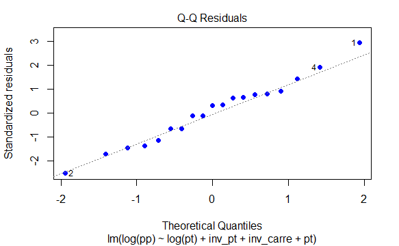

```r
plot(model3, col = "blue", pch = 19, which =2)
```

On peut voir que le QQPlot s’améliore de plus en plus lorsqu’on ajoute des 1/T…